# Recommendation System

Alena Suvorova

## Preview dataset movies

```
## Classes 'spec_tbl_df', 'tbl_df', 'tbl' and 'data.frame': 545 obs. of  22 variables:
##  $ title                  : chr  "The Avengers" "Robin Hood" "Titanic" "The Great Gatsby" ...
##  $ movie_id               : num  289 2021 3124 1270 4179 ...
##  $ budget                 : num  2.20e+08 2.00e+08 2.00e+08 1.05e+08 2.00e+08 1.90e+08 1.50e+08 1.40e+08 1.40e+08 1.00e+08 ...
##  $ genres                 : chr  "Science, Action, Adventure" "Action, Adventure" "Drama, Romance, Thriller" "Drama, Romance" ...
##  $ keywords               : chr  "new, shield, marvel, superhero, based, alien, superhero, aftercreditsstinger, duringcreditsstinger, marvel" "robin, archer, knight, sherwood, bow, middle, medieval, king" "shipwreck, iceberg, ship, panic, titanic, ocean, epic, rich, love, disaster, tragic, class,…
##  $ overview               : chr  "When an unexpected enemy emerges and threatens global safety and security, Nick Fury, director of the internati"| __truncated__ "When soldier Robin happens upon the dying Robert of Loxley, he promises to return the man's sword to his family"| __truncated__ "84 ye…
##  $ popularity             : num  144.4 37.7 100 61.2 39.7 ...
##  $ production_companies   : chr  "Paramount, Marvel" "Imagine, Universal, Scott, Relativity" "Paramount, Twentieth, Lightstorm" "Village, Bazmark, Warner, A, Red, Spectrum" ...
##  $ production_countries   : chr  "United" "United, United" "United" "United, Australia" ...
##  $ release_date           : Date, format: "1998-04-25" "1922-05-12" ...
##  $ revenue                : num  1.52e+09 3.11e+08 1.85e+09 3.51e+08 3.25e+08 ...
##  $ runtime                : num  143 140 194 143 96 130 140 151 88 90 ...
##  $ tagline                : chr  "Some assembly required." "Rise and rise again, until lambs become lions." "Nothing on Earth could come between them." "Reserving judgments is a matter of infinite hope... I come to the admission that it has a limit." ...
##  $ movie_year             : chr  "1998" "1922" "1953" "2000" ...
##  $ count_rating           : int  163 11 277 80 109 11 3782 525 9380 30 ...
##  $ average_rating         : num  2.55 3.36 3.83 3.2 4.3 ...
##  $ income                 : num  1.30e+09 1.11e+08 1.65e+09 2.46e+08 1.25e+08 ...
##  $ genres_id              : chr  "878, 28, 12" "28, 12" "18, 10749, 53" "18, 10749" ...
##  $ keywords_id            : chr  "242, 5539, 8828, 9715, 9717, 14909, 155030, 179430, 179431, 180547" "4147, 4393, 10466, 11525, 18101, 41406, 161257, 186686" "2580, 2984, 3799, 4210, 4388, 4953, 6917, 7579, 9673, 10617, 10703, 14514, 156395, 165086, 182615, 182621, 1826"| __truncated__ "818, 132…
##  $ production_companies_id: chr  "4" "23, 33, 1645" "4, 306" "79, 240, 6194, 11858, 14440" ...
##  $ production_countries_id: chr  "US" "GB, US" "US" "US, AU" ...
##  $ spoken_languages_id    : chr  "en" "en, th" "en, fr, de, sv, it, ru" "en" ...
```

## Top 10 films with the highest revenue

| title | movie_id | revenue | movie_year |
| --- | --- | --- | --- |
| Titanic | 3124 | 1845034188 | 1953 |
| The Avengers | 289 | 1519557910 | 1998 |
| Shrek 2 | 3938 | 919838758 | 2004 |
| The Sixth Sense | 4306 | 672806292 | 1999 |
| Pirates of the Caribbean: The Curse of the Black Pearl | 1905 | 655011224 | 2003 |
| The Passion of the Christ | 4266 | 611899420 | 2004 |
| Armageddon | 621 | 553799566 | 1997 |
| Sherlock Holmes | 1332 | 524028679 | 1954 |
| Ghost | 3106 | 505000000 | 1990 |
| Bruce Almighty | 3860 | 484572835 | 2003 |

## Top 10 films with the highest budget

| title | movie_id | budget | movie_year |
| --- | --- | --- | --- |
| The Avengers | 289 | 2.20e+08 | 1998 |
| Robin Hood | 2021 | 2.00e+08 | 1922 |
| Titanic | 3124 | 2.00e+08 | 1953 |
| A Christmas Carol | 4179 | 2.00e+08 | 1951 |
| Tomorrowland | 4148 | 1.90e+08 | 1955 |
| Batman Begins | 3864 | 1.50e+08 | 2005 |
| Shrek 2 | 3938 | 1.50e+08 | 2004 |
| The Alamo | 535 | 1.45e+08 | 1960 |
| Armageddon | 621 | 1.40e+08 | 1997 |
| Men in Black II | 3427 | 1.40e+08 | 2002 |

## Top 10 “disaster” movies (lowest income)

| title | movie_id | income | movie_year |
| --- | --- | --- | --- |
| The Alamo | 535 | -119180039 | 1960 |
| Town & Country | 2467 | -79627709 | 2001 |
| Monkeybone | 1525 | -69590483 | 2001 |
| Sphere | 1693 | -61900000 | 1998 |
| Final Fantasy: The Spirits Within | 1983 | -51868170 | 2001 |
| Hudson Hawk | 548 | -47781920 | 1991 |
| Turbulence | 3077 | -43533912 | 1997 |
| Heaven’s Gate | 2673 | -40515669 | 1980 |
| Jade | 55 | -40148390 | 1995 |
| The Scarlet Letter | 3497 | -39617593 | 1979 |

## Top 10 most popular movies

| title | movie_id | popularity | movie_year |
| --- | --- | --- | --- |
| Pirates of the Caribbean: The Curse of the Black Pearl | 1905 | 271.97289 | 2003 |
| The Avengers | 289 | 144.44863 | 1998 |
| Tomorrowland | 4148 | 130.31135 | 1955 |
| Spirited Away | 3446 | 118.96856 | 2002 |
| Batman Begins | 3864 | 115.04002 | 2005 |
| Bruce Almighty | 3860 | 109.68479 | 2003 |
| Titanic | 3124 | 100.02590 | 1953 |
| Psycho | 1792 | 93.06787 | 1998 |
| Men in Black II | 3427 | 91.33285 | 2002 |
| Home Alone 2: Lost in New York | 2400 | 81.48768 | 1992 |

## Top 10 most popular genres

| genre | count |
| --- | --- |
| drama | 282 |
| comedy | 215 |
| thriller | 147 |
| action | 131 |
| romance | 114 |
| adventure | 104 |
| crime | 89 |
| science | 65 |
| fantasy | 62 |
| family | 61 |

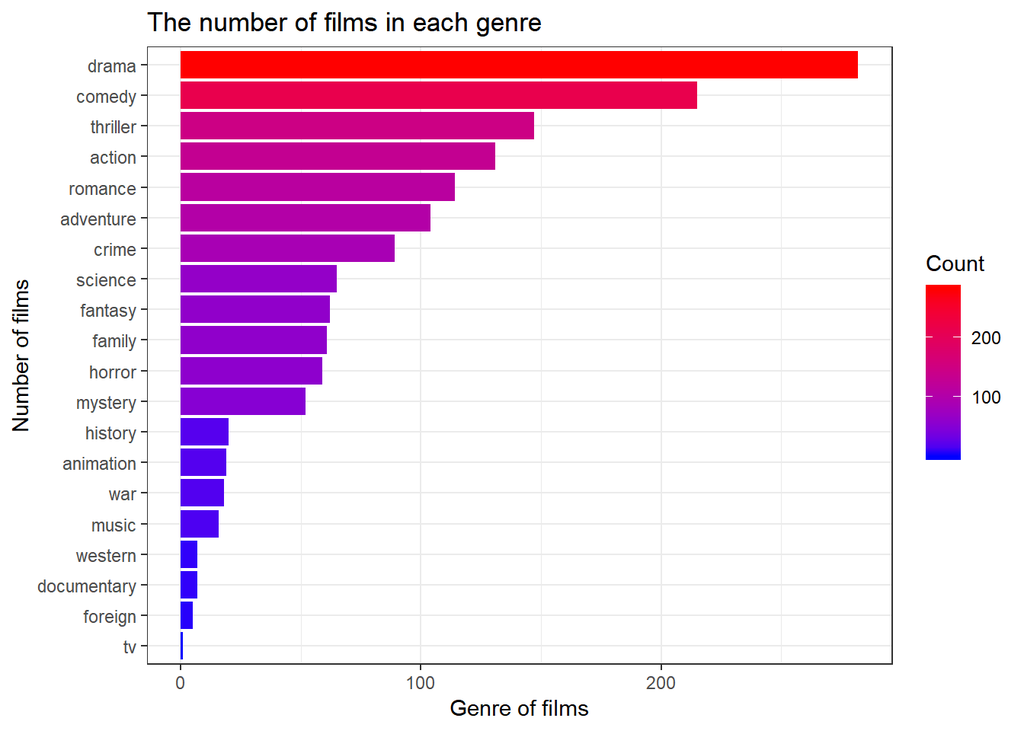

Продолжаем работать с рекомендательными системами. Сегодня рассмотрим новый пример построения рекомендательной системы в R для фильмов. В отличие от прошлого раза будем использовать не метод коллаборативной фильтрации, а content-based подходы.

### Загрузка данных

Работаем все так же с сокращенными данными о фильмах

```r
library(tidyverse)

movies <- read_csv("~/shared/minor2_2018/data/movies_cut.csv")
ratings <- read_csv("~/shared/minor2_2018/data/ratings_cut.csv")
```

### “Полезные” признаки фильмов

Сформируем набор признаков, характеризующих фильмы, и важных для построения рекомендаций. В проекте этот набор вам нужно определить по результатам разведочного анализа, анализа сетей и текстов, включения дополнительных данных. В рамках лабораторной этот этап сократим и отберем ряд признаков “вручную”.

Пусть нам интересны * средняя оценка фильма по отзывам * популярность * жанры * длина слогана * есть ли цифры в названии

Оставляем только нужные переменные в датасете

```r
movies = movies %>% dplyr::select(title, movie_id, genres, popularity, tagline)
```

Считаем среднюю оценку фильма

```r
data = ratings %>% group_by(movie_id) %>% summarize(rating = mean(rating, na.rm = T))
```

Объединяем датасеты.

- Почему используется inner_join? В чем было бы отличие результирующего датасета при применении left_join?

```r
data = inner_join(data, movies)
```

Определяем наличие цифр в названии и длину слогана

```r
library(stringr)
data = data %>% mutate(digitsTitle = str_detect(data$title, "[0-9]"))
data = data %>% mutate(tlLength = str_length(data$tagline))
```

Преобразуем жанры

```r
library(tidyr)
source("~/shared/minor2_2018/2-tm-net/extract_json.R")

data = extract_json(df = data, col = "genres")
```

Удалаем лишние переменные

```r
data = data %>% dplyr::select(-tagline, -title, -genres)
```

## Distribution of the number of films produced by month

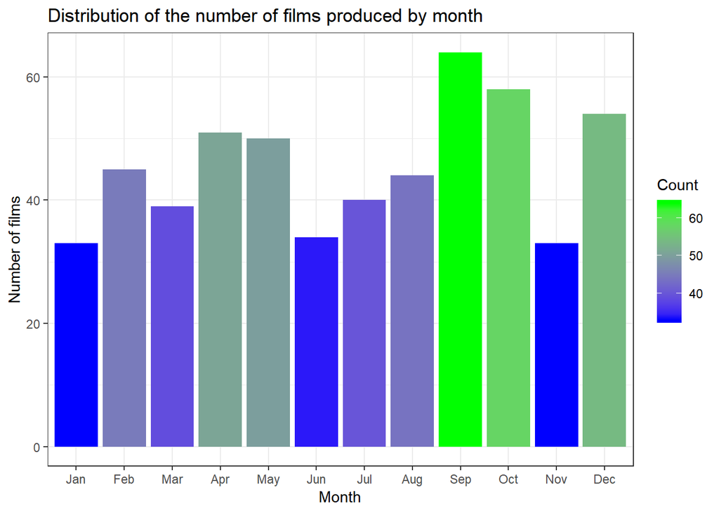

## Distribution of the number of films produced by year

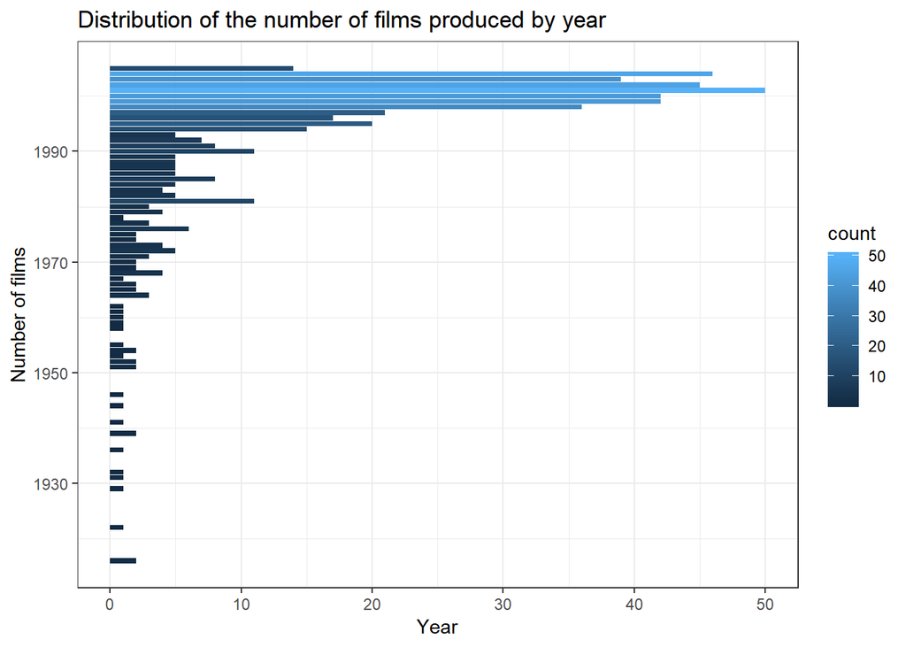

## Annalys keywords

### Frequence of keywords

#### Wordscloud

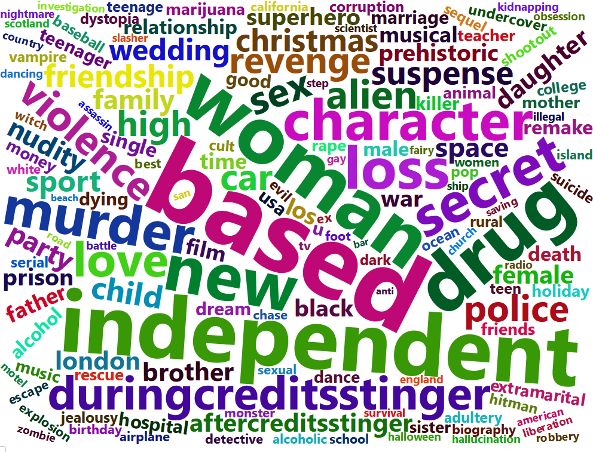

#### Top 10 words in keywords most popular

Frequence of keywords

| words | count | rating_key |
| --- | --- | --- |
| based | 58 | 3.513242 |
| independent | 47 | 3.338847 |
| woman | 44 | 3.352126 |
| drug | 42 | 3.319667 |
| new | 37 | 3.382947 |
| loss | 32 | 3.650491 |
| character | 31 | 3.210572 |
| secret | 31 | 3.474129 |
| murder | 30 | 3.181206 |
| love | 26 | 3.402219 |

### Sentiments score of keywords

Keywords with extreme sentiment (point = -5, -4, 4, 5) are rarely used

| words | count | rating_key | score |
| --- | --- | --- | --- |
| rape | 9 | 3.275760 | -4 |
| torture | 2 | 3.661292 | -4 |
| fraud | 1 | 3.281081 | -4 |
| shrew | 1 | 3.784102 | -4 |
| tortured | 1 | 3.520231 | -4 |
| loss | 32 | 3.650491 | -3 |
| violence | 23 | 3.404292 | -3 |
| evil | 8 | 3.269656 | -3 |
| illegal | 6 | 3.341106 | -3 |
| conspiracy | 4 | 3.361553 | -3 |

| words | count | rating_key | score |
| --- | --- | --- | --- |
| fantastic | 1 | 3.593750 | 4 |
| love | 26 | 3.402219 | 3 |
| good | 10 | 3.666657 | 3 |
| best | 7 | 3.021574 | 3 |
| great | 4 | 3.509555 | 3 |
| marvel | 4 | 3.007845 | 3 |
| fan | 3 | 3.794355 | 3 |
| super | 3 | 3.551586 | 3 |
| amusement | 2 | 3.759263 | 3 |
| luck | 2 | 3.031505 | 3 |

### Distribution of the set sentiment of keywords in each genre

Distribution of the set sentiment of keywords in each genre

|  | anger | anticipation | disgust | fear | joy | negative | positive | sadness | surprise | trust | mean_rating | count |
| --- | --- | --- | --- | --- | --- | --- | --- | --- | --- | --- | --- | --- |
| action | 139 | 89 | 68 | 191 | 66 | 239 | 151 | 104 | 72 | 110 | 3.383012 | 131 |
| adventure | 89 | 72 | 47 | 134 | 65 | 159 | 143 | 64 | 60 | 77 | 3.405703 | 104 |
| animation | 18 | 22 | 11 | 24 | 27 | 25 | 40 | 14 | 16 | 24 | 3.670037 | 19 |
| comedy | 135 | 161 | 116 | 197 | 154 | 285 | 248 | 145 | 82 | 177 | 3.376458 | 215 |
| crime | 137 | 94 | 80 | 197 | 61 | 230 | 112 | 113 | 73 | 96 | 3.378183 | 89 |
| documentary | 3 | 3 | 2 | 4 | 4 | 6 | 4 | 2 | 3 | 2 | 3.857158 | 7 |
| drama | 273 | 232 | 169 | 397 | 206 | 491 | 373 | 294 | 138 | 265 | 3.428952 | 282 |
| family | 46 | 62 | 30 | 65 | 63 | 74 | 89 | 42 | 42 | 62 | 3.474364 | 61 |
| fantasy | 50 | 53 | 37 | 77 | 52 | 89 | 86 | 35 | 33 | 57 | 3.372460 | 62 |
| foreign | 1 | 0 | 1 | 1 | 1 | 3 | 2 | 1 | 1 | 2 | 3.319439 | 5 |
| history | 10 | 10 | 7 | 16 | 9 | 23 | 24 | 6 | 9 | 16 | 3.611820 | 20 |
| horror | 82 | 49 | 69 | 134 | 27 | 136 | 67 | 68 | 35 | 51 | 3.291486 | 59 |
| music | 13 | 15 | 4 | 11 | 22 | 20 | 34 | 19 | 15 | 20 | 3.630806 | 16 |
| mystery | 72 | 58 | 49 | 111 | 44 | 109 | 67 | 58 | 37 | 53 | 3.289635 | 52 |
| romance | 67 | 81 | 51 | 97 | 91 | 135 | 155 | 85 | 45 | 94 | 3.415516 | 114 |
| science | 52 | 44 | 48 | 105 | 24 | 111 | 68 | 42 | 23 | 43 | 3.256713 | 65 |
| thriller | 182 | 133 | 112 | 276 | 86 | 303 | 163 | 151 | 100 | 136 | 3.288396 | 147 |
| tv | 0 | 0 | 0 | 1 | 0 | 1 | 0 | 0 | 0 | 0 | 2.666667 | 1 |
| war | 27 | 18 | 10 | 40 | 15 | 44 | 45 | 20 | 12 | 22 | 3.660020 | 18 |
| western | 13 | 2 | 7 | 17 | 2 | 21 | 7 | 9 | 3 | 5 | 3.342675 | 7 |

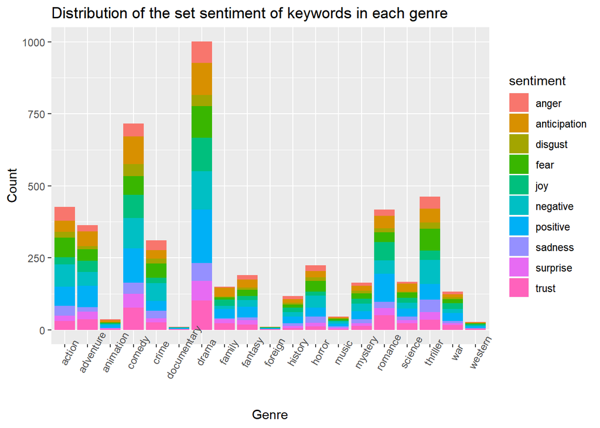

### Distribution negative/positive keywords in each genres

Genre drama has the most number of negative keywords

| genre | negative | positive |
| --- | --- | --- |
| drama | 311 | 104 |
| comedy | 211 | 60 |
| thriller | 206 | 51 |
| crime | 157 | 30 |
| action | 147 | 42 |
| horror | 99 | 21 |
| adventure | 97 | 45 |
| romance | 90 | 54 |
| mystery | 80 | 20 |
| science | 73 | 29 |
| fantasy | 56 | 32 |
| family | 55 | 28 |
| war | 27 | 12 |
| animation | 17 | 9 |
| history | 12 | 5 |
| music | 12 | 1 |
| western | 12 | 1 |
| documentary | 3 | 1 |
| foreign | 1 | 0 |

### Now we will calculate sum sentiment in each genre.

Genre drama has the lowest level of sum sentiment score, then thriller and crime

| genre | count | score |
| --- | --- | --- |
| drama | 319 | -361 |
| thriller | 187 | -299 |
| crime | 133 | -229 |
| action | 137 | -163 |
| comedy | 167 | -152 |
| horror | 83 | -113 |
| mystery | 72 | -109 |
| science | 78 | -59 |
| adventure | 98 | -56 |
| war | 35 | -36 |
| family | 50 | -18 |
| western | 10 | -18 |
| romance | 107 | -16 |
| history | 12 | -12 |
| tv | 1 | -2 |
| fantasy | 47 | -1 |
| animation | 16 | 0 |
| music | 9 | 1 |
| documentary | 5 | 2 |

[output not shown]

## Annalys tagline

### Frequence of words used in tagline

#### Wordscloud

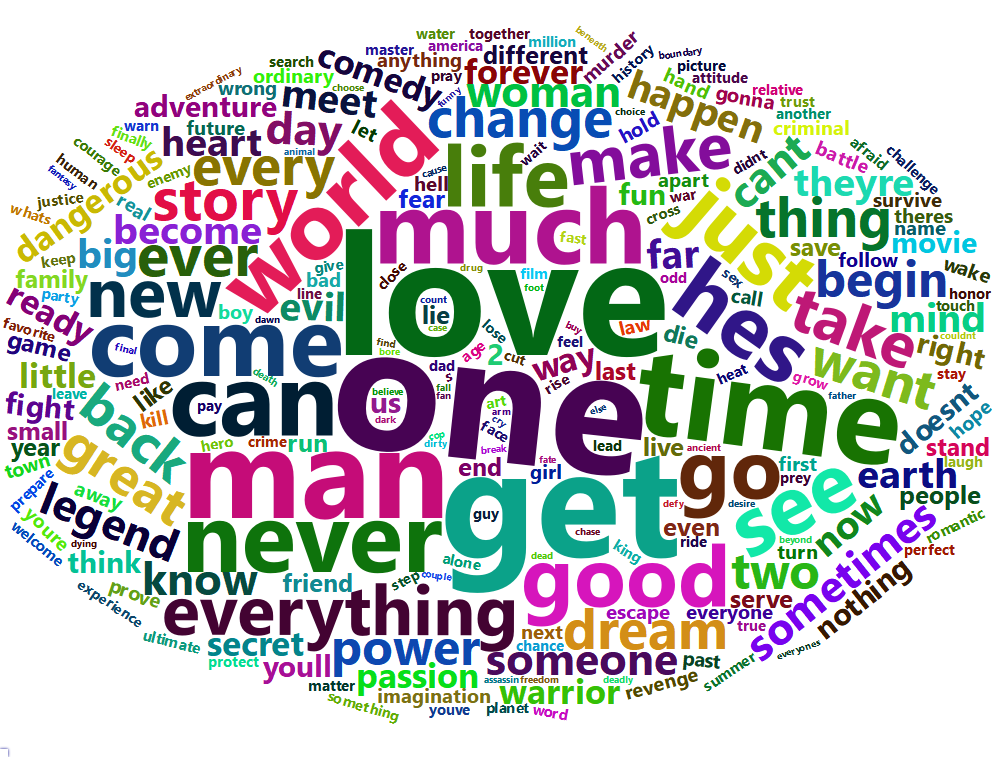

| words | count | rating |
| --- | --- | --- |
| bless | 1 | 4.322085 |
| gift | 1 | 4.322085 |
| enter | 1 | 4.307535 |
| killer | 1 | 4.307535 |
| madman | 1 | 4.307535 |
| greedings | 1 | 4.302752 |
| season | 1 | 4.302752 |
| truly | 1 | 4.284385 |
| knight | 1 | 4.242993 |
| confidence | 1 | 4.214286 |

#### Film producers rarely use words in tagline with extreme sentiments (sentiment with score -5,-4,4,5)

Arrangement words in tagline by increasing score of sentiment

| words | count | rating | score |
| --- | --- | --- | --- |
| hell | 4 | 3.302374 | -4 |
| loser | 1 | 4.043021 | -3 |
| treason | 1 | 3.987500 | -3 |
| loathe | 1 | 3.784102 | -3 |
| damage | 1 | 3.765403 | -3 |
| hate | 1 | 3.733667 | -3 |
| die | 5 | 3.577867 | -3 |
| cruel | 1 | 3.575758 | -3 |
| deception | 1 | 3.523913 | -3 |
| evil | 8 | 3.373917 | -3 |

Arrangement words in tagline by decreasing score of sentiment

| words | count | rating | score |
| --- | --- | --- | --- |
| masterpiece | 2 | 4.069696 | 4 |
| winner | 1 | 4.043021 | 4 |
| win | 1 | 3.773857 | 4 |
| miracle | 1 | 3.570043 | 4 |
| fun | 6 | 3.556229 | 4 |
| funny | 2 | 3.355601 | 4 |
| wonderful | 1 | 2.666667 | 4 |
| excitement | 1 | 3.848070 | 3 |
| happiness | 1 | 3.554951 | 3 |
| love | 34 | 3.503304 | 3 |

## Analysis overview

### Frequence of words in overviews

#### Wordscloud

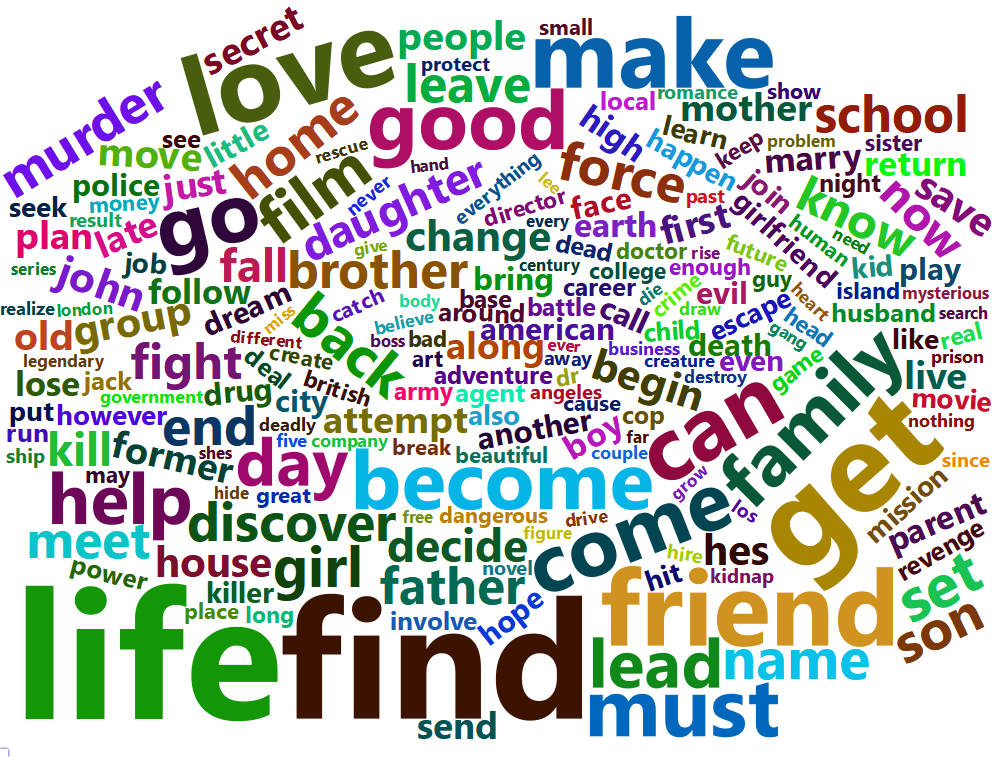

#### Top 10 words in overviews most popular

Top 10 words used in overviews most popular

[output not shown]

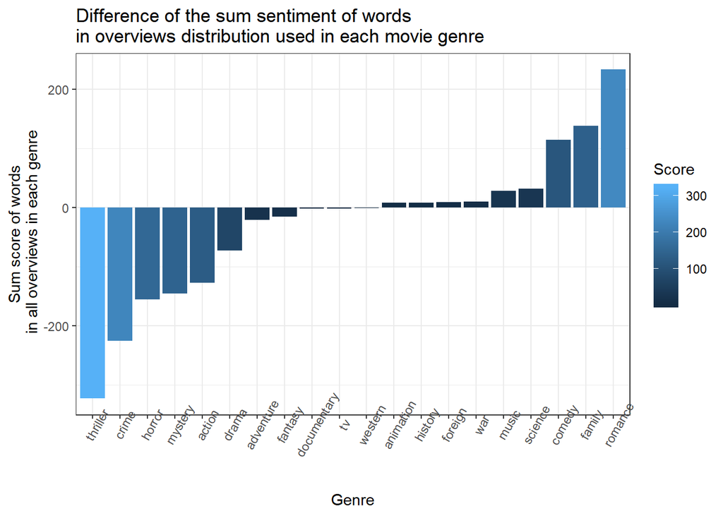

[output not shown]

#### As in keywords and tagline, film producers also rarely use words in overviews with extreme sentiments (sentiment with score -5,-4,4,5)

Arrangement of words in overviews by decreasing level of sentiment score

| words | count | score |
| --- | --- | --- |
| awesome | 1 | 4 |
| brilliant | 4 | 4 |
| fantastic | 1 | 4 |
| fun | 3 | 4 |
| masterpiece | 1 | 4 |
| terrific | 1 | 4 |
| win | 9 | 4 |
| winner | 2 | 4 |
| adorable | 1 | 3 |
| affection | 3 | 3 |

| words | count | score |
| --- | --- | --- |
| catastrophic | 1 | -4 |
| damn | 1 | -4 |
| dick | 2 | -4 |
| fraud | 1 | -4 |
| hell | 9 | -4 |
| rape | 3 | -4 |
| rapist | 1 | -4 |
| abhorrent | 1 | -3 |
| abuse | 3 | -3 |
| abusive | 1 | -3 |

### Схожесть фильмов

Считаем матрицу схожести фильмов

```r
rownames(data) = data$movie_id
data = data %>% dplyr::select(-movie_id)
sim = lsa::cosine(t(as.matrix(data)))
```

Посмотрим на первые несколько фильмов

```r
sim[1:5, 1:5]
```

```
##           4492      4488      4483      4482      4479
## 4492 1.0000000 0.9947638 0.9928004 0.9956963 0.9908817
## 4488 0.9947638 1.0000000 0.9963980 0.9876268 0.9992370
## 4483 0.9928004 0.9963980 1.0000000 0.9840844 0.9943884
## 4482 0.9956963 0.9876268 0.9840844 1.0000000 0.9822477
## 4479 0.9908817 0.9992370 0.9943884 0.9822477 1.0000000
```

Нам нужно искать наиболее похожие фильмы, т.е. фильмы с большими значениями схожести.

```r
max(sim[,"4488"])
```

```
## [1] NA
```

Это значит, что в столбце есть пропущенные значения. Посчитаем максимум без их учета

```r
max(sim[,"4488"], na.rm = T)
```

```
## [1] 1
```

Но это не id фильма, а показатель схожести. поэтому используем немного другую функцию, чтобы получить не значение, а индекс строки

```r
mostSimilar = max(sim[,"4488"], na.rm = T)
a = which(sim[,"4488"] == mostSimilar, arr.ind = TRUE)
a
```

```
## 4488
##    2
```

Это именованный вектор с индексом той строки, где схожесть максимальна. id фильма можно получить или по индексу из общего списка названий строк, или, выбрав имена вектора a

```r
rownames(sim)[a]
```

```
## [1] "4488"
```

```r
names(a)
```

```
## [1] "4488"
```

Однако, больше всего фильмы похожи сами на себя, что неинтересно, поэтому до поиска “содержательного” максимального значения лучше заменить диагональные элементы, например, на 0

```r
diag(sim) = 0
mostSimilar = max(sim[,"4488"], na.rm = T)
a = which(sim[,"4488"] == mostSimilar, arr.ind = TRUE)
names(a)
```

```
## [1] "3890"
```

Само значение схожести

```r
mostSimilar
```

```
## [1] 0.9996963
```

### Рекомендация

Но так мы нашли схожие фильмы. Осталось собственно сделать рекомендацию.

Возьмем, к примеру, пользователя 111343. Отберем фильмы, которые ему понравились

```r
user = ratings %>% filter(customer_id == 111343 & rating == 5)
user
```

```
## # A tibble: 1 x 7
##      X1 customer_id rating rating_date movie_id movie_year title
##   <dbl>       <dbl>  <dbl> <date>         <dbl>      <dbl> <chr>
## 1  5110      111343      5 2004-03-25       571       1999 American Beauty
```

```r
user$movie_id
```

```
## [1] 571
```

Ищем фильмы, похожие на 571 (“American Beauty”)

```r
mostSimilar = max(sim[,as.character(user$movie_id)], na.rm = T)
a = which(sim[,as.character(user$movie_id)] == mostSimilar, arr.ind = TRUE)
names(a)
```

```
## [1] "3860"
```

Т.е. наша рекомендация фильм 3860. Осталось найти его название

```r
filter(movies,movie_id == 3860) %>% select(title)
```

```
## # A tibble: 1 x 1
##   title
##   <chr>
## 1 Bruce Almighty
```

Прописывать id фильма каждый раз вручную – не самая удобная стратегия (почему?), поэтому лучше сохраним результат в переменную и используем ее

```r
result = names(a)
filter(movies,movie_id == result) %>% select(title)
```

```
## # A tibble: 1 x 1
##   title
##   <chr>
## 1 Bruce Almighty
```

А если мы хотим порекомендовать не один фильм, а несколько? Как найти, например, 5 наиболее похожих?

```r
mostSimilar = head(sort(sim[,as.character(user$movie_id)], decreasing = T), n = 5)
mostSimilar
```

```
##      3860      1905       289      1770      3864
## 0.9996800 0.9992965 0.9992165 0.9990170 0.9989900
```

Обратите внимание, что в этом случае у нас сразу есть нужные имена (id фильмов)

```r
result = names(mostSimilar)
filter(movies,movie_id %in% result) %>% dplyr::select(title)
```

```
## # A tibble: 5 x 1
##   title
##   <chr>
## 1 The Avengers
## 2 Batman Begins
## 3 Pirates of the Caribbean: The Curse of the Black Pearl
## 4 Bruce Almighty
## 5 Trainspotting
```

В рассматриваемом примере у пользователя был всего один фильм с оценкой 5. А что, если их несколько?

```r
userId = 2413408
user = ratings %>% filter(customer_id == userId & rating == 5)
user$movie_id
```

```
## [1]  607 1073 1905 2152 2913 3825 3860 3938 4306
```

Мы все равно можем найти максимальное значение схожести по всем фильмам сразу

```r
mostSimilar = max(sim[,as.character(user$movie_id)], na.rm = T)
a = which(sim[,as.character(user$movie_id)] == mostSimilar, arr.ind = TRUE)
a
```

```
##      row col
## 2192 256   2
```

Максимальный элемент расположен в 256 строке и 2 колонке матрицы sim[,as.character(user$movie_id)], но проще id получить из названия строк – 2192

```r
result = rownames(a)
filter(movies,movie_id %in% result) %>% dplyr::select(title)
```

```
## # A tibble: 1 x 1
##   title
##   <chr>
## 1 The Hurricane
```

А если хотим получить несколько рекомендаций?

```r
mostSimilar = head(sort(sim[,as.character(user$movie_id)], decreasing = T), n = 5)
mostSimilar
```

```
## [1] 0.9999259 0.9997629 0.9997016 0.9996923 0.9996800
```

Сейчас у нас нет имен, поэтому возврщаемся к функции which

```r
a = which(sim[,as.character(user$movie_id)] %in% mostSimilar, arr.ind = TRUE)
a ## выдается результат "общим" индексом, а не строки-столбцы, нам нужны строки
```

```
## [1]  763 1494 1670 3475 3522
```

```r
rows = a %% dim(sim)[1]
rows
```

```
## [1] 256 480 149 433 480
```

```r
result = rownames(sim)[rows]
result
```

```
## [1] "2192" "289"  "3282" "571"  "289"
```

```r
filter(movies,movie_id %in% result) %>% dplyr::select(title, movie_id)
```

```
## # A tibble: 4 x 2
##   title           movie_id
##   <chr>              <dbl>
## 1 The Avengers         289
## 2 The Hurricane       2192
## 3 Sideways            3282
## 4 American Beauty      571
```

Фильм The Avengers оказался дважды в топ-5 по похожести на 9 фильмов с оценкой 5. Можно посмотреть, на что именно он похож

```r
cols = a %/% dim(sim)[1]
user$movie_id[cols]
```

```
## [1]  607 1073 1905 3825 3825
```

```r
data.frame(userFilm = user$movie_id[cols], similarFilm = result, similarity = mostSimilar)
```

```
##   userFilm similarFilm similarity
## 1      607        2192  0.9999259
## 2     1073         289  0.9997629
## 3     1905        3282  0.9997016
## 4     3825         571  0.9996923
## 5     3825         289  0.9996800
```

- Что делать, если у пользователя нет фильмов с оценкой 5? Ваши предложения?

```r
userId = 964421
user = ratings %>% filter(customer_id == userId & rating == 5)
user$movie_id
```

```
## numeric(0)
```

**Ваша очередь**: Выведите в рекомендации не только названия фильмов, но и степень похожести и среднюю оценку фильма. Упорядочите результат по похожести.